# Communicate Data Findings - Exploration of Loan Data from Prosper

## by Scholastica Olanrewaju

Preliminary Wrangling  
Univariate Exploration  
Bivariate Exploration  
Multivariate Exploration

## Preliminary Wrangling

This document explores a data set containing **113,937** loans with 81 variables on each loan, including loan amount, borrower rate (or interest rate), current loan status, borrower income, and many others.

```python
# import all packages and set plots to be embedded inline
import numpy as np
import pandas as pd
import matplotlib.pyplot as plt
import seaborn as sb
from mpl_toolkits.mplot3d import Axes3D

%matplotlib inline
```

```python
#Set to display complete contents of a dataframe without any kind of truncation
pd.set_option('display.max_rows', None)
pd.set_option('display.max_columns', None)
pd.set_option('display.width', None)
pd.set_option('display.max_colwidth', None)
```

```python
#load in the dataset into a pandas dataframe
loan = pd.read_csv('prosperLoanData.csv')
```

```python
#View dataset
print(loan.shape)
loan.sample(5)
```

```
(113937, 81)
```

|  | ListingKey | ListingNumber | ListingCreationDate | CreditGrade | Term | LoanStatus | ClosedDate | BorrowerAPR | BorrowerRate | LenderYield | EstimatedEffectiveYield | EstimatedLoss | EstimatedReturn | ProsperRating (numeric) | ProsperRating (Alpha) | ProsperScore | ListingCategory (numeric) | BorrowerState | Occupation | EmploymentStatus | EmploymentStatusDuration | IsBorrowerHomeowner | CurrentlyInGroup | GroupKey | DateCreditPulled | CreditScoreRangeLower | CreditScoreRangeUpper | FirstRecordedCreditLine | CurrentCreditLines | … |
| --- | --- | --- | --- | --- | --- | --- | --- | --- | --- | --- | --- | --- | --- | --- | --- | --- | --- | --- | --- | --- | --- | --- | --- | --- | --- | --- | --- | --- | --- | --- |
| 84493 | 4E38359757569320408F59C | 1096967 | 2013-12-26 11:58:52.403000000 | NaN | 36 | Current | NaN | 0.14714 | 0.1189 | 0.1089 | 0.10446 | 0.0374 | 0.06706 | 6.0 | A | 7.0 | 1 | TX | Sales - Commission | Employed | 32.0 | True | False | NaN | 2013-12-26 11:58:56 | 700.0 | 719.0 | 1987-08-04 00:00:00 | 14.0 | … |
| 75000 | B8293581477591174451B59 | 805418 | 2013-06-12 01:37:05.043000000 | NaN | 60 | Current | NaN | 0.26877 | 0.2432 | 0.2332 | 0.21480 | 0.0975 | 0.11730 | 3.0 | D | 4.0 | 1 | IN | Police Officer/Correction Officer | Employed | 360.0 | True | False | NaN | 2013-06-30 17:14:41 | 660.0 | 679.0 | 1985-10-01 00:00:00 | 11.0 | … |
| 89753 | 66CF35958999889171DCFE7 | 1065575 | 2013-12-10 10:42:32.520000000 | NaN | 36 | Current | NaN | 0.20524 | 0.1685 | 0.1585 | 0.14814 | 0.0699 | 0.07824 | 4.0 | C | 5.0 | 1 | KY | Professional | Employed | 77.0 | False | False | NaN | 2013-12-10 10:42:34 | 640.0 | 659.0 | 1993-06-01 00:00:00 | 5.0 | … |
| 61508 | 0C983459439219450521A24 | 420315 | 2009-08-12 18:54:33.897000000 | NaN | 36 | Completed | 2012-08-20 00:00:00 | 0.22338 | 0.2010 | 0.1910 | 0.12160 | 0.0650 | 0.12160 | 4.0 | C | 9.0 | 7 | MD | Teacher | Full-time | 46.0 | True | False | NaN | 2009-08-12 18:49:30 | 680.0 | 699.0 | 1999-04-05 00:00:00 | 8.0 | … |
| 9603 | 0B5735019164415568A9ADF | 485994 | 2010-11-28 18:13:40.583000000 | NaN | 36 | Completed | 2013-03-18 00:00:00 | 0.31308 | 0.2775 | 0.2675 | 0.16280 | 0.0980 | 0.16280 | 3.0 | D | 7.0 | 2 | WI | Analyst | Employed | 2.0 | True | False | NaN | 2010-11-28 18:13:36 | 660.0 | 679.0 | 2000-05-10 00:00:00 | 2.0 | … |

```python
#Assess columns
print(list(loan.columns))
loan.sample(10)
```

```
['ListingKey', 'ListingNumber', 'ListingCreationDate', 'CreditGrade', 'Term', 'LoanStatus', 'ClosedDate', 'BorrowerAPR', 'BorrowerRate', 'LenderYield', 'EstimatedEffectiveYield', 'EstimatedLoss', 'EstimatedReturn', 'ProsperRating (numeric)', 'ProsperRating (Alpha)', 'ProsperScore', 'ListingCategory …
```

|  | ListingKey | ListingNumber | ListingCreationDate | CreditGrade | Term | LoanStatus | ClosedDate | BorrowerAPR | BorrowerRate | LenderYield | EstimatedEffectiveYield | EstimatedLoss | EstimatedReturn | ProsperRating (numeric) | ProsperRating (Alpha) | ProsperScore | ListingCategory (numeric) | BorrowerState | Occupation | EmploymentStatus | EmploymentStatusDuration | IsBorrowerHomeowner | CurrentlyInGroup | GroupKey | DateCreditPulled | CreditScoreRangeLower | CreditScoreRangeUpper | FirstRecordedCreditLine | CurrentCreditLines | … |
| --- | --- | --- | --- | --- | --- | --- | --- | --- | --- | --- | --- | --- | --- | --- | --- | --- | --- | --- | --- | --- | --- | --- | --- | --- | --- | --- | --- | --- | --- | --- |
| 46329 | 92D83601079264871C5E27A | 1160967 | 2014-01-26 12:56:05.660000000 | NaN | 36 | Current | NaN | 0.06726 | 0.0605 | 0.0505 | 0.05000 | 0.0074 | 0.04260 | 7.0 | AA | 11.0 | 1 | WI | Professional | Employed | 3.0 | False | False | NaN | 2014-01-26 12:56:08 | 820.0 | 839.0 | 1997-10-23 00:00:00 | 14.0 | … |
| 34278 | 01C23398471231848B9E132 | 199598 | 2007-09-09 17:24:29.850000000 | C | 36 | Chargedoff | 2009-01-21 00:00:00 | 0.16751 | 0.1495 | 0.1395 | NaN | NaN | NaN | NaN | NaN | NaN | 0 | FL | Retail Management | Full-time | 0.0 | True | False | NaN | 2007-08-28 18:20:22.057000000 | 640.0 | 659.0 | 1993-06-18 00:00:00 | 14.0 | … |
| 90287 | 4E123408214629206500243 | 247750 | 2007-12-09 20:42:07.980000000 | B | 36 | Chargedoff | 2010-03-22 00:00:00 | 0.14709 | 0.1400 | 0.1300 | NaN | NaN | NaN | NaN | NaN | NaN | 4 | CA | Executive | Full-time | 124.0 | True | True | NaN | 2007-12-02 12:54:23.423000000 | 700.0 | 719.0 | 1987-08-19 00:00:00 | 10.0 | … |
| 32364 | 82C235122659746273BB914 | 501787 | 2011-04-11 15:35:07.720000000 | NaN | 36 | Chargedoff | 2012-09-28 00:00:00 | 0.35643 | 0.3199 | 0.3099 | 0.29170 | 0.1830 | 0.10870 | 1.0 | HR | 4.0 | 2 | MI | Sales - Commission | Employed | 85.0 | False | False | NaN | 2011-04-11 15:34:54 | 640.0 | 659.0 | 1989-09-01 00:00:00 | 9.0 | … |
| 10595 | CC3334109571481345BEFFF | 272088 | 2008-01-27 12:47:36.280000000 | B | 36 | Completed | 2011-02-08 00:00:00 | 0.16436 | 0.1500 | 0.1400 | NaN | NaN | NaN | NaN | NaN | NaN | 1 | FL | Professional | Full-time | 131.0 | True | False | NaN | 2008-01-27 12:30:09.990000000 | 680.0 | 699.0 | 1994-06-06 00:00:00 | 14.0 | … |
| 62858 | 6CA23603049672485E5F0F3 | 1235091 | 2014-02-26 06:24:17.073000000 | NaN | 36 | Current | NaN | 0.22301 | 0.1855 | 0.1755 | 0.16252 | 0.0849 | 0.07762 | 4.0 | C | 2.0 | 1 | SC | Professional | Self-employed | 66.0 | False | False | NaN | 2014-02-26 06:24:19 | 700.0 | 719.0 | 2009-06-15 00:00:00 | 7.0 | … |
| 37831 | 340A3602127458119E2A022 | 1153930 | 2014-02-11 09:33:49.117000000 | NaN | 60 | Current | NaN | 0.24882 | 0.2235 | 0.2135 | 0.19571 | 0.1075 | 0.08821 | 3.0 | D | 3.0 | 1 | FL | Retail Management | Employed | 23.0 | False | False | NaN | 2014-02-06 08:25:17 | 660.0 | 679.0 | 2002-12-12 00:00:00 | 8.0 | … |
| 40145 | B539359764096811571AC57 | 1094388 | 2013-12-18 10:26:24.847000000 | NaN | 60 | Current | NaN | 0.16969 | 0.1465 | 0.1365 | 0.12898 | 0.0549 | 0.07408 | 5.0 | B | 9.0 | 2 | CA | Retail Management | Employed | 110.0 | False | False | NaN | 2013-12-18 10:26:27 | 660.0 | 679.0 | 2001-08-18 00:00:00 | 5.0 | … |
| 36499 | 7A6D3591590784588840C7F | 954385 | 2013-10-22 05:19:56.340000000 | NaN | 36 | Current | NaN | 0.13189 | 0.1039 | 0.0939 | 0.09071 | 0.0299 | 0.06081 | 6.0 | A | 10.0 | 1 | PA | Professional | Employed | 122.0 | True | False | NaN | 2013-12-18 07:04:36 | 700.0 | 719.0 | 1997-02-04 00:00:00 | 14.0 | … |
| 31674 | C28B3497770334814890845 | 482674 | 2010-11-03 05:04:10.570000000 | NaN | 36 | Chargedoff | 2012-02-22 00:00:00 | 0.41355 | 0.3500 | 0.3400 | 0.13690 | 0.1830 | 0.13690 | 1.0 | HR | 4.0 | 1 | PA | Professional | Employed | 192.0 | True | False | NaN | 2010-10-19 18:47:52 | 660.0 | 679.0 | 1993-01-01 00:00:00 | 9.0 | … |

```python
#Select columns relevant to analysis
columns = ['ListingKey', 'ListingCreationDate','Term', 'LoanStatus','BorrowerAPR','ProsperScore',
           'ListingCategory (numeric)', 'BorrowerState', 'Occupation','EmploymentStatus',
           'IsBorrowerHomeowner','CreditScoreRangeLower', 'CreditScoreRangeUpper', 'CurrentCreditLines',
           'OpenCreditLines', 'OpenRevolvingAccounts','OpenRevolvingMonthlyPayment','CurrentDelinquencies',
           'AmountDelinquent', 'DebtToIncomeRatio', 'StatedMonthlyIncome', 'TotalProsperLoans',
           'OnTimeProsperPayments', 'LoanMonthsSinceOrigination','LoanOriginalAmount',
           'Recommendations', 'InvestmentFromFriendsCount', 'Investors']
loan = loan[columns]

#confirm
list(loan.columns)
```

```
['ListingKey',
 'ListingCreationDate',
 'Term',
 'LoanStatus',
 'BorrowerAPR',
 'ProsperScore',
 'ListingCategory (numeric)',
 'BorrowerState',
 'Occupation',
 'EmploymentStatus',
 'IsBorrowerHomeowner',
 'CreditScoreRangeLower',
 'CreditScoreRangeUpper',
 'CurrentCreditLines',
 'OpenCreditLines',
 'OpenRevolvingAccounts',
 'OpenRevolvingMonthlyPayment',
 'CurrentDelinquencies',
 'AmountDelinquent',
 'DebtToIncomeRatio',
 'StatedMonthlyIncome',
 'TotalProsperLoans',
 'OnTimeProsperPayments',
 'LoanMonthsSinceOrigination',
 'LoanOriginalAmount',
 'Recommendations',
 'InvestmentFromFriendsCount',
 'Investors']
```

```python
# Check for duplicates
sum(loan.duplicated())
```

```
0
```

```python
#check for nulls
loan.isnull().sum()
```

```
ListingKey                         0
ListingCreationDate                0
Term                               0
LoanStatus                         0
BorrowerAPR                       25
ProsperScore                   29084
ListingCategory (numeric)          0
BorrowerState                   5515
Occupation                      3588
EmploymentStatus                2255
IsBorrowerHomeowner                0
CreditScoreRangeLower            591
CreditScoreRangeUpper            591
CurrentCreditLines              7604
OpenCreditLines                 7604
OpenRevolvingAccounts              0
OpenRevolvingMonthlyPayment        0
CurrentDelinquencies             697
AmountDelinquent                7622
DebtToIncomeRatio               8554
StatedMonthlyIncome                0
TotalProsperLoans              91852
OnTimeProsperPayments          91852
LoanMonthsSinceOrigination         0
LoanOriginalAmount                 0
Recommendations                    0
InvestmentFromFriendsCount         0
Investors                          0
dtype: int64
```

```python
#Assess ProsperScore
#Confirm
loan.ProsperScore.value_counts()
```

```
4.0     12595
6.0     12278
8.0     12053
7.0     10597
5.0      9813
3.0      7642
9.0      6911
2.0      5766
10.0     4750
11.0     1456
1.0       992
Name: ProsperScore, dtype: int64
```

```python
# filter out loans without ProsperScores
loan = loan[loan['ProsperScore'].isnull()==False]

#drop prosperscore greater than 10- according to data dictionary, prosperscore ranged form 1-10 #ConsistencyIssues
loan.drop(loan.loc[loan['ProsperScore']>10].index, inplace=True)
```

```python
#Confirm
loan.ProsperScore.value_counts()
```

```
4.0     12595
6.0     12278
8.0     12053
7.0     10597
5.0      9813
3.0      7642
9.0      6911
2.0      5766
10.0     4750
1.0       992
Name: ProsperScore, dtype: int64
```

```python
#rename relevant column headers
loan.rename(index = str, columns = {'ListingCategory (numeric)': 'ListingCategory'}, inplace = True)

#confirm
list(loan.columns)
```

```
['ListingKey',
 'ListingCreationDate',
 'Term',
 'LoanStatus',
 'BorrowerAPR',
 'ProsperScore',
 'ListingCategory',
 'BorrowerState',
 'Occupation',
 'EmploymentStatus',
 'IsBorrowerHomeowner',
 'CreditScoreRangeLower',
 'CreditScoreRangeUpper',
 'CurrentCreditLines',
 'OpenCreditLines',
 'OpenRevolvingAccounts',
 'OpenRevolvingMonthlyPayment',
 'CurrentDelinquencies',
 'AmountDelinquent',
 'DebtToIncomeRatio',
 'StatedMonthlyIncome',
 'TotalProsperLoans',
 'OnTimeProsperPayments',
 'LoanMonthsSinceOrigination',
 'LoanOriginalAmount',
 'Recommendations',
 'InvestmentFromFriendsCount',
 'Investors']
```

```python
#change ListingCreationDate to date-time
loan['ListingCreationDate'] = pd.to_datetime(loan.ListingCreationDate)

#change ListingCategory from int to object
loan['ListingCategory'] = loan['ListingCategory'].astype(str)

#prosperscore too- refused to change to str
```

```python
# confirm and high-level overview of data shape and composition
print(loan.shape)
print(loan.dtypes)
print(loan.head(5))
```

```
(83397, 28)
ListingKey                             object
ListingCreationDate            datetime64[ns]
Term                                    int64
LoanStatus                             object
BorrowerAPR                           float64
ProsperScore                          float64
ListingCategory                        object
BorrowerState                          object
Occupation                             object
EmploymentStatus                       object
IsBorrowerHomeowner                      bool
CreditScoreRangeLower                 float64
CreditScoreRangeUpper                 float64
CurrentCreditLines                    float64
OpenCreditLines                       float64
OpenRevolvingAccounts                   int64
OpenRevolvingMonthlyPayment           float64
CurrentDelinquencies                  float64
AmountDelinquent                      float64
DebtToIncomeRatio                     float64
StatedMonthlyIncome                   float64
TotalProsperLoans                     float64
OnTimeProsperPayments                 float64
LoanMonthsSinceOrigination              int64
LoanOriginalAmount                      int64
Recommendations                         int64
InvestmentFromFriendsCount              int64
Investors                               int64
dtype: object
                ListingKey     ListingCreationDate  Term LoanStatus  \
1  10273602499503308B223C1 2014-02-27 08:28:07.900    36    Current
3  0EF5356002482715299901A 2012-10-22 11:02:35.010    36    Current
4  0F023589499656230C5E3E2 2013-09-14 18:38:39.097    36    Current
5  0F05359734824199381F61D 2013-12-14 08:26:37.093    60    Current
6  0F0A3576754255009D63151 2013-04-12 09:52:56.147    36    Current

   BorrowerAPR  ProsperScore ListingCategory BorrowerState      Occupation  \
1      0.12016           7.0               2            CO    Professional
3      0.12528           9.0              16            GA   Skilled Labor
```

[output cut: 30 more lines]

```
6               0.0               0.27          2083.333333

   TotalProsperLoans  OnTimeProsperPayments  LoanMonthsSinceOrigination  \
1                NaN                    NaN                           0
3                NaN                    NaN                          16
4                1.0                   11.0                           6
5                NaN                    NaN                           3
6                NaN                    NaN                          11

   LoanOriginalAmount  Recommendations  InvestmentFromFriendsCount  Investors
1               10000                0                           0          1
3               10000                0                           0        158
4               15000                0                           0         20
5               15000                0                           0          1
6                3000                0                           0          1
```

```python
loan.describe()
```

|  | Term | BorrowerAPR | ProsperScore | CreditScoreRangeLower | CreditScoreRangeUpper | CurrentCreditLines | OpenCreditLines | OpenRevolvingAccounts | OpenRevolvingMonthlyPayment | CurrentDelinquencies | AmountDelinquent | DebtToIncomeRatio | StatedMonthlyIncome | TotalProsperLoans | OnTimeProsperPayments | LoanMonthsSinceOrigination | LoanOriginalAmount | Recommendations | InvestmentFromFriendsCount | Investors |
| --- | --- | --- | --- | --- | --- | --- | --- | --- | --- | --- | --- | --- | --- | --- | --- | --- | --- | --- | --- | --- |
| count | 83397.000000 | 83397.000000 | 83397.000000 | 83397.000000 | 83397.000000 | 83397.000000 | 83397.000000 | 83397.000000 | 83397.000000 | 83397.000000 | 83397.000000 | 76145.000000 | 8.339700e+04 | 18970.000000 | 18970.000000 | 83397.000000 | 83397.000000 | 83397.000000 | 83397.000000 | 83397.000000 |
| mean | 42.482248 | 0.228663 | 5.861902 | 698.821301 | 717.821301 | 10.478207 | 9.497452 | 7.360948 | 429.180114 | 0.326618 | 962.169694 | 0.259829 | 5.880222e+03 | 1.447127 | 23.319346 | 16.254062 | 8982.621185 | 0.017291 | 0.008118 | 67.810161 |
| std | 11.654919 | 0.079011 | 2.300729 | 46.937346 | 46.937346 | 5.316531 | 4.926235 | 4.507071 | 425.127285 | 1.119809 | 7464.712419 | 0.320910 | 8.271991e+03 | 0.773509 | 19.051870 | 13.905727 | 6202.474999 | 0.187729 | 0.110131 | 94.190355 |
| min | 12.000000 | 0.045830 | 1.000000 | 600.000000 | 619.000000 | 0.000000 | 0.000000 | 0.000000 | 0.000000 | 0.000000 | 0.000000 | 0.000000 | 0.000000e+00 | 0.000000 | 0.000000 | 0.000000 | 1000.000000 | 0.000000 | 0.000000 | 1.000000 |
| 25% | 36.000000 | 0.167320 | 4.000000 | 660.000000 | 679.000000 | 7.000000 | 6.000000 | 4.000000 | 155.000000 | 0.000000 | 0.000000 | 0.150000 | 3.416667e+03 | 1.000000 | 9.000000 | 5.000000 | 4000.000000 | 0.000000 | 0.000000 | 1.000000 |
| 50% | 36.000000 | 0.221400 | 6.000000 | 700.000000 | 719.000000 | 10.000000 | 9.000000 | 7.000000 | 310.000000 | 0.000000 | 0.000000 | 0.220000 | 5.000000e+03 | 1.000000 | 17.000000 | 12.000000 | 7500.000000 | 0.000000 | 0.000000 | 32.000000 |
| 75% | 60.000000 | 0.293410 | 8.000000 | 720.000000 | 739.000000 | 13.000000 | 12.000000 | 10.000000 | 561.000000 | 0.000000 | 0.000000 | 0.320000 | 7.083333e+03 | 2.000000 | 33.000000 | 25.000000 | 13000.000000 | 0.000000 | 0.000000 | 96.000000 |
| max | 60.000000 | 0.423950 | 10.000000 | 880.000000 | 899.000000 | 59.000000 | 54.000000 | 50.000000 | 13765.000000 | 51.000000 | 463881.000000 | 10.010000 | 1.750003e+06 | 8.000000 | 141.000000 | 56.000000 | 35000.000000 | 19.000000 | 9.000000 | 1189.000000 |

```python
#store clean dataset in csv
loan.to_csv('loan_clean.csv', encoding = 'utf-8', index = False)

#load in the dataset into a pandas dataframe
df = pd.read_csv('loan_clean.csv')

#confirm
print(df.shape)
df.sample(5)
```

```
(83397, 28)
```

|  | ListingKey | ListingCreationDate | Term | LoanStatus | BorrowerAPR | ProsperScore | ListingCategory | BorrowerState | Occupation | EmploymentStatus | IsBorrowerHomeowner | CreditScoreRangeLower | CreditScoreRangeUpper | CurrentCreditLines | OpenCreditLines | OpenRevolvingAccounts | OpenRevolvingMonthlyPayment | CurrentDelinquencies | AmountDelinquent | DebtToIncomeRatio | StatedMonthlyIncome | TotalProsperLoans | OnTimeProsperPayments | LoanMonthsSinceOrigination | LoanOriginalAmount | Recommendations | InvestmentFromFriendsCount | Investors |
| --- | --- | --- | --- | --- | --- | --- | --- | --- | --- | --- | --- | --- | --- | --- | --- | --- | --- | --- | --- | --- | --- | --- | --- | --- | --- | --- | --- | --- |
| 31376 | 011F36017480631615D2954 | 2014-01-24 15:40:37.340 | 36 | Completed | 0.19501 | 4.0 | 7 | MI | Sales - Retail | Employed | True | 660.0 | 679.0 | 6.0 | 6.0 | 3 | 236.0 | 1.0 | 65.0 | 0.21 | 2416.666667 | NaN | NaN | 2 | 3800 | 0 | 0 | 1 |
| 7171 | E2E73534929473622DE85AD | 2011-12-19 08:04:19.663 | 36 | Current | 0.14358 | 8.0 | 1 | PA | Accountant/CPA | Employed | True | 780.0 | 799.0 | 17.0 | 16.0 | 16 | 665.0 | 0.0 | 0.0 | 0.35 | 5000.000000 | NaN | NaN | 27 | 25000 | 0 | 0 | 9 |
| 6625 | AAF13590346442309CDC794 | 2013-10-08 14:49:15.797 | 36 | Current | 0.13301 | 5.0 | 1 | HI | Attorney | Self-employed | False | 720.0 | 739.0 | 33.0 | 33.0 | 22 | 797.0 | 0.0 | 0.0 | NaN | 8166.666667 | NaN | NaN | 5 | 15000 | 0 | 0 | 291 |
| 11163 | 12CF3600951497223DEFFE3 | 2014-01-23 17:54:55.893 | 36 | Current | 0.17151 | 6.0 | 1 | FL | Teacher | Employed | False | 680.0 | 699.0 | 12.0 | 10.0 | 8 | 283.0 | 0.0 | 0.0 | 0.36 | 3225.000000 | NaN | NaN | 2 | 10000 | 0 | 0 | 7 |
| 26257 | 033635987056358805F189F | 2013-12-27 11:46:55.183 | 36 | Current | 0.27776 | 4.0 | 1 | NY | Other | Employed | True | 640.0 | 659.0 | 14.0 | 13.0 | 11 | 953.0 | 0.0 | 0.0 | 0.22 | 8000.000000 | NaN | NaN | 2 | 10000 | 0 | 0 | 4 |

### What is/are the main feature(s) of interest in your dataset?

I'm most interested in figuring out what features are best for predicting a borrower's annual percentage rate (APR).

### What features in the dataset do you think will help support your investigation into your feature(s) of interest?

I expect the following features to have either a positive/negative effect on borrower's rating. Stated monthly income, prosper score, credit score, employment status, loan original amount, on time prosper payments, debt to income ratio and recommendations. Among all these, I expect the prosper score and loan original amount to have teh strongest effect.

## Univariate Exploration

In this section, I investigate distributions of individual variables. Unusual points/utliers were examined at a deeper level. This was achieved using appropriate chart for each variable type.  
I will start by looking at the main variable of interest- BorrowerAPR

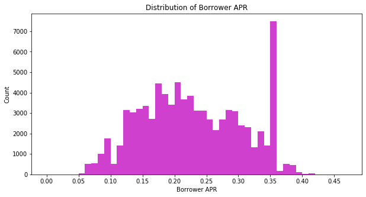

```python
#Plot histogram to see distribution of borrowe APR
bins = np.arange(0, df.BorrowerAPR.max()+0.05, 0.01)

plt.figure(figsize=[10, 5])
plt.hist(data = df, x = 'BorrowerAPR', bins = bins, facecolor='m', alpha=0.75);
plt.title('Distribution of Borrower APR')
plt.xlabel('Borrower APR')
plt.ylabel('Count')
plt.xticks(np.arange(0, df['BorrowerAPR'].max()+0.05, 0.05));
```

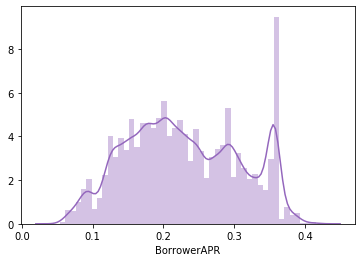

```python
#Distplot of Borrowers APR
sb.distplot(df['BorrowerAPR'], color=sb.color_palette()[4]);
```

```python
# Check loans with APR greater than 0.43
df[df.BorrowerAPR>=0.42]
```

|  | ListingKey | ListingCreationDate | Term | LoanStatus | BorrowerAPR | ProsperScore | ListingCategory | BorrowerState | Occupation | EmploymentStatus | IsBorrowerHomeowner | CreditScoreRangeLower | CreditScoreRangeUpper | CurrentCreditLines | OpenCreditLines | OpenRevolvingAccounts | OpenRevolvingMonthlyPayment | CurrentDelinquencies | AmountDelinquent | DebtToIncomeRatio | StatedMonthlyIncome | TotalProsperLoans | OnTimeProsperPayments | LoanMonthsSinceOrigination | LoanOriginalAmount | Recommendations | InvestmentFromFriendsCount | Investors |
| --- | --- | --- | --- | --- | --- | --- | --- | --- | --- | --- | --- | --- | --- | --- | --- | --- | --- | --- | --- | --- | --- | --- | --- | --- | --- | --- | --- | --- |
| 77531 | CC0C3497369291932E3CF0E | 2010-10-22 14:07:40.683 | 36 | Chargedoff | 0.42395 | 4.0 | 7 | NH | Administrative Assistant | Employed | False | 720.0 | 739.0 | 9.0 | 6.0 | 7 | 115.0 | 1.0 | 1047.0 | 0.08 | 2250.0 | NaN | NaN | 40 | 1000 | 0 | 0 | 42 |

```python
# Check loans with APR less than 0.05
df[df.BorrowerAPR<0.05]
```

|  | ListingKey | ListingCreationDate | Term | LoanStatus | BorrowerAPR | ProsperScore | ListingCategory | BorrowerState | Occupation | EmploymentStatus | IsBorrowerHomeowner | CreditScoreRangeLower | CreditScoreRangeUpper | CurrentCreditLines | OpenCreditLines | OpenRevolvingAccounts | OpenRevolvingMonthlyPayment | CurrentDelinquencies | AmountDelinquent | DebtToIncomeRatio | StatedMonthlyIncome | TotalProsperLoans | OnTimeProsperPayments | LoanMonthsSinceOrigination | LoanOriginalAmount | Recommendations | InvestmentFromFriendsCount | Investors |
| --- | --- | --- | --- | --- | --- | --- | --- | --- | --- | --- | --- | --- | --- | --- | --- | --- | --- | --- | --- | --- | --- | --- | --- | --- | --- | --- | --- | --- |
| 1378 | 367234574528085749991E3 | 2009-07-17 09:21:37.610 | 36 | Completed | 0.04583 | 10.0 | 3 | NY | Military Enlisted | Full-time | False | 740.0 | 759.0 | 7.0 | 6.0 | 4 | 50.0 | 0.0 | 0.0 | 0.05 | 4583.333333 | 1.0 | 17.0 | 49 | 1000 | 1 | 1 | 23 |
| 7023 | 0C0B3499722393755B476D1 | 2010-11-04 12:56:29.977 | 12 | Completed | 0.04935 | 10.0 | 7 | NC | Analyst | Full-time | True | 800.0 | 819.0 | 6.0 | 5.0 | 4 | 61.0 | 0.0 | 0.0 | 0.04 | 4166.666667 | 2.0 | 6.0 | 40 | 1000 | 1 | 0 | 20 |
| 77970 | D66835007571979327BA235 | 2010-11-15 11:54:57.440 | 12 | Completed | 0.04935 | 10.0 | 2 | UT | Professional | Full-time | True | 840.0 | 859.0 | 8.0 | 7.0 | 6 | 77.0 | 0.0 | 0.0 | 0.04 | 4166.666667 | NaN | NaN | 40 | 1000 | 0 | 1 | 22 |

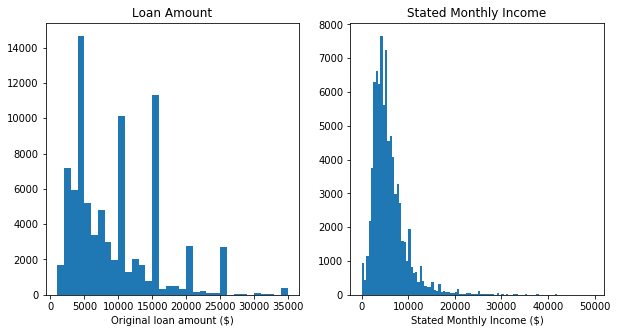

```python
plt.figure(figsize = [10,5])

plt.subplot(1,2,1)
bins = np.arange(df.LoanOriginalAmount.min(), df.LoanOriginalAmount.max()+1e3, 1e3)
plt.hist(data = df, x = 'LoanOriginalAmount', bins = bins);
plt.xlabel('Original loan amount ($)')
plt.title('Loan Amount');

plt.subplot(1,2,2)
# Distribution of stated monthly income
bins_inc = np.arange(0, 50000, 500)
plt.hist(data = df, x = 'StatedMonthlyIncome', bins=bins_inc)
plt.xlabel('Stated Monthly Income ($)')
plt.title('Stated Monthly Income');
```

```python
#Get range for log values of lan amount
np.log10(df.LoanOriginalAmount.describe())
```

```
count    4.921150
mean     3.953403
std      3.792565
min      3.000000
25%      3.602060
50%      3.875061
75%      4.113943
max      4.544068
Name: LoanOriginalAmount, dtype: float64
```

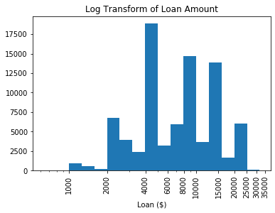

```python
#Use log transformation for loan original amount
bins = 10 ** np.arange(2.8, 4.5+0.1, 0.1)
ticks = [1000, 2000, 4000, 6000, 8000, 10000, 15000, 20000, 25000,
         30000,35000]
labels = ['{}'.format(val) for val in ticks]
plt.hist(data = df, x = 'LoanOriginalAmount', bins = bins)
plt.xscale('log')
plt.xticks(ticks, labels, rotation = 90 )
plt.xlabel('Loan ($)')
plt.title('Log Transform of Loan Amount');
```

# Use log transformation for stated monthly income

```python
#check values for log prior to transform to determine range
print(df.StatedMonthlyIncome.describe())
print(np.log10(df.StatedMonthlyIncome.describe()))
```

```
count    8.339700e+04
mean     5.880222e+03
std      8.271991e+03
min      0.000000e+00
25%      3.416667e+03
50%      5.000000e+03
75%      7.083333e+03
max      1.750003e+06
Name: StatedMonthlyIncome, dtype: float64
count    4.921150
mean     3.769394
std      3.917610
min          -inf
25%      3.533603
50%      3.698970
75%      3.850238
max      6.243039
Name: StatedMonthlyIncome, dtype: float64
```

> **Loan Amount**: This is multimodial with large spikes in frequency at 4000, 10000, 15000, 20000 and 25000. Smaller frequency spikes are observed at almost nth 1000 indicating that loans were frequently taken in multiples of 1000.  
> The distribution is right-skewed with the reduced frequency in loans above 25000. This distribution was mainited in a log transform.

> **Stated Monthly Income**: As commonly observed with financial data, this was skewed to the right. This shows that fewer people had higher income.  
> I thought to do a log transform for the visualisation but was witheld by the log of the minimum value= -inf. At this stage, I do not have the knowledge to handle this appropriately.

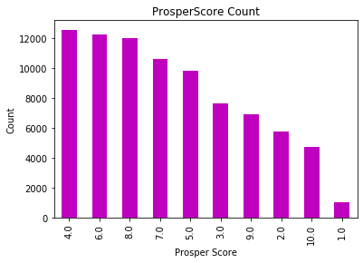

```python
#Plot prosper score
plt.figsize=(10,10)
df['ProsperScore'].value_counts().plot(kind='bar', color ='m')
plt.title('ProsperScore Count')
plt.xlabel('Prosper Score')
plt.ylabel('Count');
```

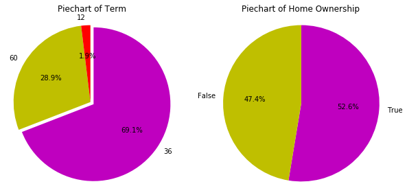

```python
plt.figure(figsize = [10,5])

plt.subplot(1,2,1)
#Proportion of loans by term
sorted_counts = df['Term'].value_counts()
plt.pie(sorted_counts, explode = (0.05, 0, 0), labels = sorted_counts.index, autopct='%1.1f%%',
        colors = ('m', 'y', 'r'), startangle = 90, counterclock = False);
plt.axis('square')
plt.title('Piechart of Term');

plt.subplot(1,2,2)
#Proportion of home ownership
sorted_counts = df['IsBorrowerHomeowner'].value_counts()
plt.pie(sorted_counts, labels = sorted_counts.index, autopct='%1.1f%%',
        colors = ('m', 'y'), startangle = 90, counterclock = False);
plt.axis('square')
plt.title('Piechart of Home Ownership');
```

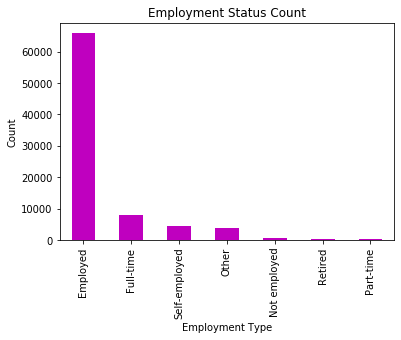

```python
#Plot employment status
plt.figsize=(10,10)
df['EmploymentStatus'].value_counts().plot(kind='bar', color ='m')
plt.title('Employment Status Count')
plt.xlabel('Employment Type')
plt.ylabel('Count');
```

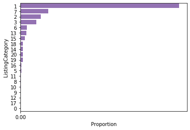

```python
#Plot Listing category
# get order of bars by frequency
listing_counts = df['ListingCategory'].value_counts()
listing_order = listing_counts.index

# compute largest proportion
n_listing = df['ListingKey'].unique().shape[0]
max_listing_count = listing_counts[0]
max_prop = max_listing_count / n_listing

# establish tick locations and create plot
base_color = sb.color_palette()[4]
tick_props = np.arange(0, max_prop, 0.02)
tick_names = ['{:0.2f}'.format(v) for v in tick_props]

sb.countplot(data = df, y = 'ListingCategory', color = base_color, order = listing_order)
plt.xticks(tick_props * n_listing, tick_names)
plt.xlabel('Proportion');
```

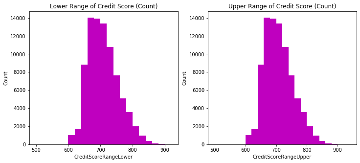

```python
# Histogram for credit score

plt.figure(figsize = [12, 5])

plt.subplot(1, 2, 1)
bins = np.arange(500, df['CreditScoreRangeLower'].max()+50, 20)
plt.hist(data = df, x = 'CreditScoreRangeLower', bins = bins, color ='m')
plt.xticks(np.arange(500, 1000, 100))
plt.title('Lower Range of Credit Score (Count)')
plt.xlabel('CreditScoreRangeLower')
plt.ylabel('Count');

plt.subplot(1, 2, 2)
bins = np.arange(500, df['CreditScoreRangeUpper'].max()+50, 20)
plt.hist(data = df, x = 'CreditScoreRangeUpper', bins = bins, color='m')
plt.xticks(np.arange(500, 1000, 100))
plt.title('Upper Range of Credit Score (Count)')
plt.xlabel('CreditScoreRangeUpper')
plt.ylabel('Count');
```

> **Credit Score**: Both CreditScoreRange (upper and lower) showed similar normal distribution- which is expected as credits are arranged in fixed ratio. Most borrowers had a score around the 650-750, with few having a score above 800 or below 600.There were no outliers observed

### Discuss the distribution(s) of your variable(s) of interest. Were there any unusual points? Did you need to perform any transformations?

`BorrowerAPR` was multimodial - with peaks at 0.10, 0.20, 0.30 and 0.36. The highest peak was observed at 0.36 with most values between 0.05 and 0.4.  
The lowest and highest `BorrowerAPR` were assessed to identify pattern. This led to a further analysis of `StatedMonthlyIncome` and `LoanAmount`.  
No transformation was performed on `StatedMonthlyIncome`

## Bivariate Exploration

In this section, I build on output from the univariate exploration to investigate relationships between pairs of variables. To start off, I want to look at pairwise correlations present between feature of the data.

```python
#group varables
numeric_vars = ['BorrowerAPR', 'LoanOriginalAmount', 'StatedMonthlyIncome','ProsperScore', 'CreditScoreRangeUpper']
categoric_vars = ['Term', 'IsBorrowerHomeowner', 'ListingCategory']
```

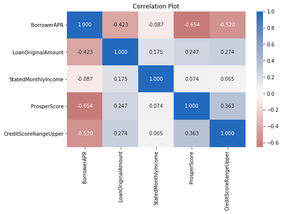

```python
#Correlation plot
plt.figure(figsize = [8, 5])
sb.heatmap(df[numeric_vars].corr(), annot = True, fmt = '.3f',
           cmap = 'vlag_r', center = 0)
plt.title('Correlation Plot');
```

**Correlation Plot**: Relationship between pairs were negative or very weak positive. There are no strong positive relationships between any pairs. As expeceted, the relationship between`BorrowerAPR` and `ProsperScore` and `BorrowerAPR` and `CreditScoreRangeUpper`are negative because borrowers with lower score (either Prosper and/or credit) are more likely to pay higher APR. Conversely, higher score means the borrowers are more creditworthy and get lower APR.  
A negative relationship was also obeserved between `LoanOriginalAmount` and `BorrowerAPR` indicating that as the loan amount increases, APR decreases. It will be interesting to investigate the effect as `Term` on this relationship as it is possible that `BorrowerAPR` is lower as bigger `LoanOriginalAmount` has longer `Term` for payback. Weak positive correlation was observed between the following pairs - `LoanOriginalAmount` and `ProsperScore`; `LoanOriginalAmount` and `CreditScoreRangeUpper`; `LoanOriginalAmount` and `StatedMonthlyIncome`. This is intuitive as borrowers with more monthly income have better rating and can access higher loans.

A correlation of 0.074 was observed between `StatedMonthlyIncome` and `ProperScore` while `StatedMonthlyIncome` and `CreditScoreRangeUpper` recorded 0.065. This is expected as people with higher income have higher credit rating.

Next, let's see the scatter plot to pair up all above variables.

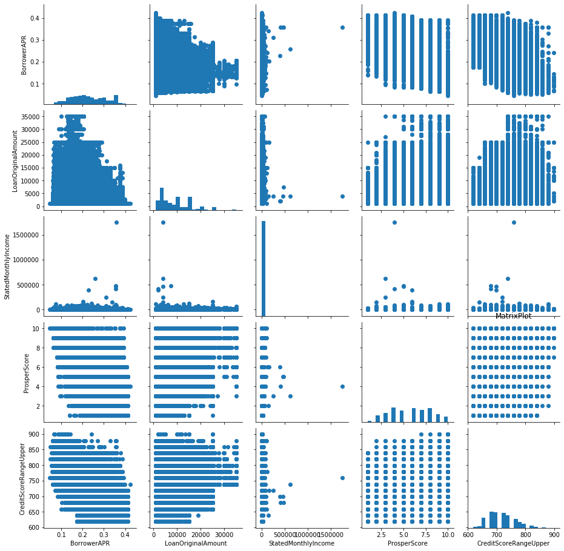

```python
# plot matrix: sample 500 loans so that plots are clearer and render faster
samples = np.random.choice(df.shape[0], 500, replace = False)
loan_samp = df.loc[samples,:]

g = sb.PairGrid(data = df, vars = numeric_vars)
g = g.map_diag(plt.hist, bins = 20);
g.map_offdiag(plt.scatter)
plt.title('MatrixPlot');
```

**Matrix Plot**: This is in line with the observations from the correlation plot. As expected, `BorrowerAPR` has negative correlation with `LoanOriginalAmount`, `ProsperScore` and `CreditScoreRangeUpper` with `ProsperScore` being the most correlated.  
This plot confirms the weak positive correlation between `LoanOriginalAmount`, `ProsperScore` and `CreditScoreRangeUpper` as expected.  
Surprisingly, the relationship between `StatedMonthlyIncome` and other data features are too weak to be of importance. Therefore, `StatedMonthlyIncome` will not be analsyed further.

Let's make more plots to look at`BorrowerAPR` vs`LoanOriginalAmount`, `BorrowerAPR` vs `ProsperScore` and `BorrowerAPR` vs `CreditScoreRangeUpper`

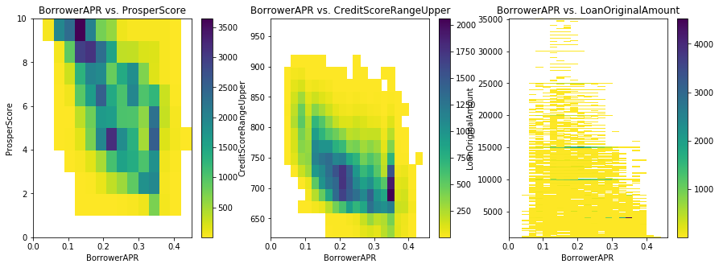

```python
#heatplot for comparing BrrowerAPR with other key variables

plt.figure(figsize = [15, 5])

plt.subplot(1, 3, 1)
bins_x = np.arange(0, df['BorrowerAPR'].max()+0.05, 0.03)
bins_y = np.arange(0, df['ProsperScore'].max()+1, 1)
plt.hist2d(data = df, x = 'BorrowerAPR', y = 'ProsperScore', bins = [bins_x, bins_y],
               cmap = 'viridis_r', cmin = 0.5)
plt.colorbar()
plt.title('BorrowerAPR vs. ProsperScore')
plt.xlabel('BorrowerAPR')
plt.ylabel('ProsperScore');


plt.subplot(1, 3, 2)
bins_x = np.arange(0, df['BorrowerAPR'].max()+0.05, 0.02)
bins_y = np.arange(df['CreditScoreRangeUpper'].min(), df['CreditScoreRangeUpper'].max()+100, 20)
plt.hist2d(data = df, x = 'BorrowerAPR', y = 'CreditScoreRangeUpper', bins = [bins_x, bins_y],
               cmap = 'viridis_r', cmin = 0.5)
plt.colorbar()
plt.title('BorrowerAPR vs. CreditScoreRangeUpper')
plt.xlabel('BorrowerAPR')
plt.ylabel('CreditScoreRangeUpper');


plt.subplot(1, 3, 3)
bins_x = np.arange(0, df['BorrowerAPR'].max()+0.05, 0.02)
bins_y = np.arange(df['LoanOriginalAmount'].min(), df['LoanOriginalAmount'].max()+100, 20)
plt.hist2d(data = df, x = 'BorrowerAPR', y = 'LoanOriginalAmount', bins = [bins_x, bins_y],
               cmap = 'viridis_r', cmin = 0.5)
plt.colorbar()
plt.title('BorrowerAPR vs. LoanOriginalAmount')
plt.xlabel('BorrowerAPR')
plt.ylabel('LoanOriginalAmount');
```

**Heat plot**  
`ProsperScore`- Borrowers with higher rating tend to be more reliable and havelower BorrowerAPR  
`CreditScoreRangeUpper`- Shows that the higher CreditScore has lower APR percentage.  
`LoanOriginalAmount`- shows increased realtionship are peak points - 4k, 10, 15k etc where the frequency of loans is highest.

Let's move on to looking at how these key numeric variables relates with the categorical variables

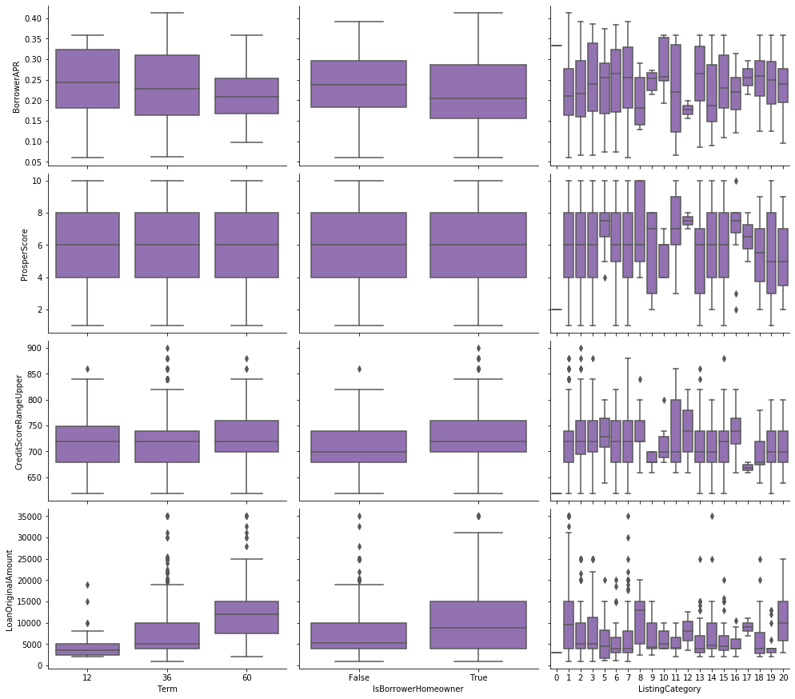

```python
# plot matrix of numeric features against categorical features.
# used a larger sample since there are fewer plots and they're simpler in nature.

samples = np.random.choice(df.shape[0], 3000, replace = False)
loan_samp = df.loc[samples,:]

def boxgrid(x, y, **kwargs):
    """ Quick hack for creating box plots with seaborn's PairGrid. """
    default_color = sb.color_palette()[4]
    sb.boxplot(x, y, color = default_color)

plt.figure(figsize = [10, 10])
g = sb.PairGrid(data = loan_samp, y_vars = ['BorrowerAPR', 'ProsperScore', 'CreditScoreRangeUpper',
                                                'LoanOriginalAmount'], x_vars = categoric_vars,
                height = 3, aspect = 1.5)
g.map(boxgrid)
plt.show();
```

Borrowers that are home owners (cc: `IsBorrowerHomeowner` has lower `BorrowerAPR` compared to non-home owners. The data visuals shows that the `LoanOriginalAmount` increases with the increase of loan `Term`. Surprisingly, homwownership has no effect on `ProsperScore`; Although home owners have higher `CreditScoreRangeUpper` and `LoanOriginalAmount`.  
As a final step in the bivariate exploration, let's look at relationships between the three categorical features.

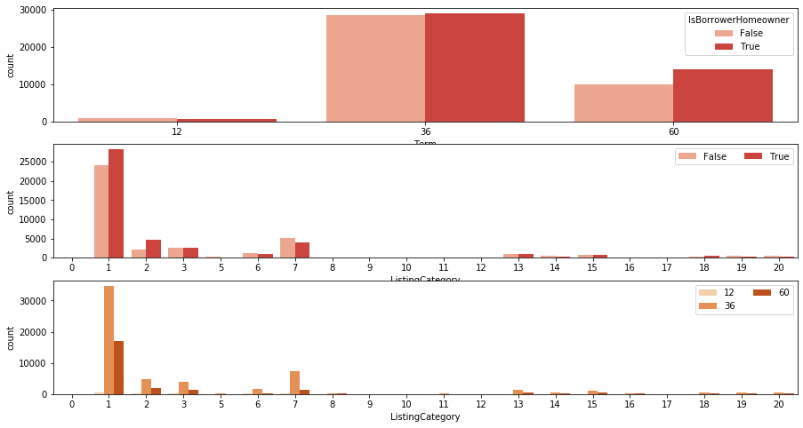

```python
# since there's only three subplots to create, using the full data should be fine.
plt.figure(figsize = [15, 8])

# subplot 1: term vs IsBorrowerHomeowner
plt.subplot(3, 1, 1)
sb.countplot(data = df, x = 'Term', hue = 'IsBorrowerHomeowner', palette = 'Reds')

# subplot 2: ListingCategory vs. IsBorrowerHomeowner
ax = plt.subplot(3, 1, 2)
sb.countplot(data = df, x = 'ListingCategory', hue = 'IsBorrowerHomeowner', palette = 'Reds')
ax.legend(ncol = 2) # re-arrange legend to reduce overlapping

# subplot 3: term vs. listingcategory, use different color palette
ax = plt.subplot(3, 1, 3)
sb.countplot(data = df, x = 'ListingCategory', hue = 'Term', palette = 'Oranges')
ax.legend(loc = 1, ncol = 2) # re-arrange legend to remove overlapping

plt.show();
```

### Talk about some of the relationships you observed in this part of the investigation. How did the feature(s) of interest vary with other features in the dataset?

`BorrowerAPR` has the strongest negative relationship with `ProsperScore`. The scatterplots also suggests a negative relationship between `BorrowerAPR` and the following variable - `LoanOriginalAmount`, `CreditScoreRangeUpper`. Therefore, as `BorrowerAPR` increases, `ProsperScore`, `LoanOriginalAmount` and `CreditScoreRangeUpper` is expected to decrease.  
Surprisingly, the relationship with `StateMonthlyIncome` was too weak. It would have been great to assess this with the full data in a log transformation as the data in the normal state is right-skewed. However, a log of the minimum value equaled '-inf' which make a log transform impossible.  
Assessing the relationship between `BorrowerAPR` and categorical variables, it was also observed that `BorrowerAPR` was lower among home owners.

### Did you observe any interesting relationships between the other features (not the main feature(s) of interest)?

A negative relationship obeserved between `LoanOriginalAmount` and `BorrowerAPR`. It was also found that `LoanOriginalAmount` increases with the increase of loan `Term`. It will be interesting to investigate the effect of `Term` on this relationship.  
Weak positive correlation were observed between the following pairs - `LoanOriginalAmount` and `ProsperScore`; `LoanOriginalAmount` and `CreditScoreRangeUpper`; and `LoanOriginalAmount` and `StatedMonthlyIncome`. This is intuitive as borrowers with more monthly income have better rating and can access higher loans.  
Surprisingly, home ownership has no effect on ProsperScore; although home owners have higher CreditScoreRangeUpper and LoanOriginalAmount.

## Multivariate Exploration

In this section, I will create plots of three or more variables to investigate the data even further. The investigations follow from the results of analysis in the bivariate exploration.

[figure not shown]

```python
#facetgrid
g = sb.FacetGrid(data = df, col = 'Term', col_wrap = 4, height = 3)
g.map(sb.regplot, 'BorrowerAPR', 'ProsperScore', scatter_kws={'alpha': 0.1})
g.set_xlabels('BorrowerAPR')
g.set_ylabels('LoanOriginalAmount')

plt.show();
```

[figure not shown]

```python
#facetgrid
g = sb.FacetGrid(data = df, col = 'IsBorrowerHomeowner', col_wrap = 4, height = 3)
g.map(sb.regplot, 'BorrowerAPR', 'ProsperScore', scatter_kws={'alpha': 0.1})
g.set_xlabels('BorrowerAPR')
g.set_ylabels('LoanOriginalAmount')

plt.show();
```

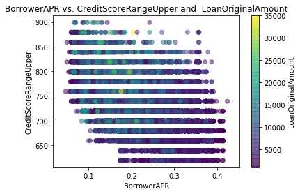

```python
#facetgrid
plt.scatter(data = df, x = 'BorrowerAPR', y = 'CreditScoreRangeUpper', c ='LoanOriginalAmount', alpha = 0.5)
plt.colorbar(label = 'LoanOriginalAmount')
plt.title('BorrowerAPR vs. CreditScoreRangeUpper and  LoanOriginalAmount')
plt.xlabel('BorrowerAPR')
plt.ylabel('CreditScoreRangeUpper');
```

`CreditScoreRangeUpper` increase as `BorrowerAPR` decrease in the plots. By adding `LoanOriginalAmount` to color encodings, we can see that `LoanOriginalAmount` decreases as `BorrowerAPR` increases. This further confirms that proves the point that `CreditScoreRangeUpper` and `LoanOriginalAmount` are negatively correlated to BorrowerAPR.